# Solar Insolation

AnnaClaire Marley

5/17/2020

## Calculate projected solar energy output in CA given solar radiation projections

#### **Workflow**

**Clean and process**

- Read in solar insolation raster data projected for California in 2050
- Reproject, crop, and mask to California
- Read in average, max, and min daily temperature data projected for California in 2050
- Reproject, crop, and mask to California

```r
# Create a Root to Extract Files
if(Sys.info()["sysname"] == "Windows"){ #If operating system is "Windows" use G: Drive
  team_path <- "G:/"
} else { # If it is not (i.e. Mac), use the Google Drive File Stream
  team_path <- "/Volumes/GoogleDrive/"
}

#Create the Full File Path
path <- paste0(team_path, "Shared drives/ESM232/Data")
```

**CRS**

```r
# Assign projection: NAD83
NAD83 <- "+proj=aea +lat_1=29.5 +lat_2=45.5 +lat_0=23 +lon_0=-96 +x_0=0 +y_0=0 +datum=NAD83
+units=m +no_defs +ellps=GRS80 +towgs84=0,0,0 "
```

## Clean and Process Data

```r
# function to read in raster data, create a raster stack, and rename files to months of the year
# folder_path: string of name of the folder as "/folder_name"

process_rasters = function(folder_path){

  #generate a list of input rasters
  #pattern = "*.tif$" - filters for main raster files only and skips any associated files (e.g.   world files)
  rasters <- list.files(paste0(path, folder_path) ,
                             pattern = "*.tif$")

  #create a raster stack from the input raster files
  raster_stack <- raster::stack(paste0(paste0(path, paste0(folder_path, "/")), rasters))

  # rename bands
  names(raster_stack) <- c("jan", "feb", "mar", "apr", "may", "jun",
                        "jul", "aug", "sep", "oct", "nov", "dec")

  return(raster_stack)
}
```

**Make California shapefile**

```r
# grab US states from maps package
california <- st_as_sf(maps::map("state", plot = FALSE, fill = TRUE)) %>%
  filter(ID == "california")

# make the polygon the same CRS as rasters
california_project <- st_transform(california, NAD83)
```

**Crop and mask rasters to California**

```r
# function to reproject, crop and mask all rasters to california

# raster: the raster files
# project: the projection you want to reproject the raster to
# polygon: california_project
ca_crop_mask = function(raster, project, polygon){

  reproject <- projectRaster(raster, crs = project)
  crop <- crop(reproject, polygon)
  mask <- mask(crop, polygon)

  return(mask)
}
```

#### Net surface radiation (W/m^2)

- Model: CCSM3
- Emission scenario: A2
- Year: 2050

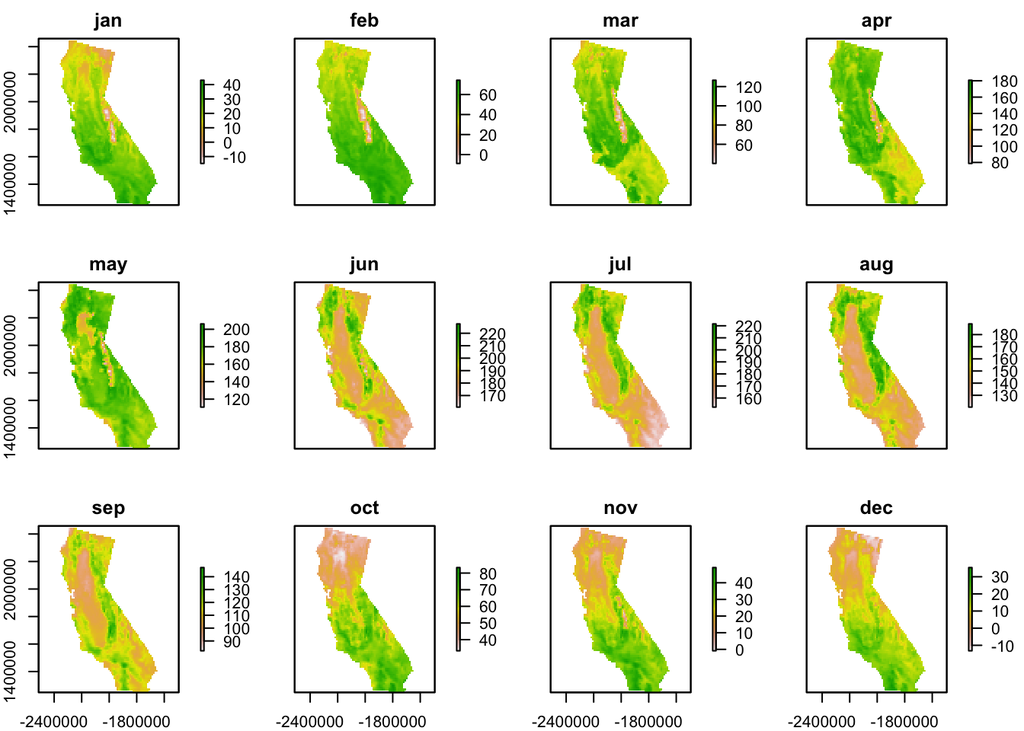

```r
# net average surface radiation
solar_stack <- process_rasters(folder_path = "/nrad_flx_ccsm3a2bcsd")

# crop and mask to ca
solar_stack_mask <- ca_crop_mask(solar_stack, NAD83, california_project)

# plot
plot(solar_stack_mask)
```

- Model: CCSM3
- Emission scenario: A2
- Year: 2050

#### Average Daily

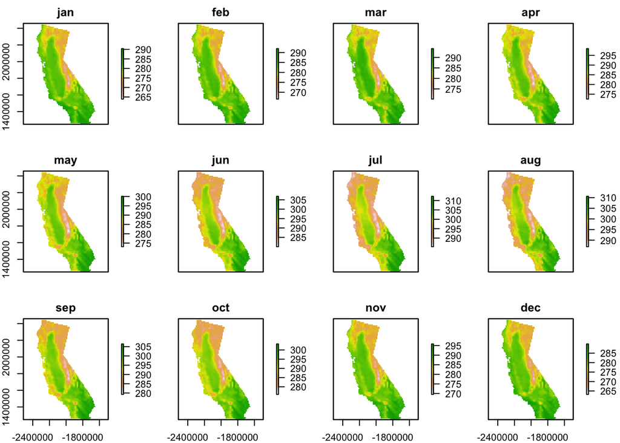

```r
#generate a list of input rasters
temp_stack <- process_rasters(folder_path = "/tav_2050")

# crop and mask to ca
temp_stack_mask <- ca_crop_mask(temp_stack, NAD83, california_project)

# convert to Kelvin
tav_K <- temp_stack_mask + 273.15

# plot
plot(tav_K)
```

#### Average Maximum

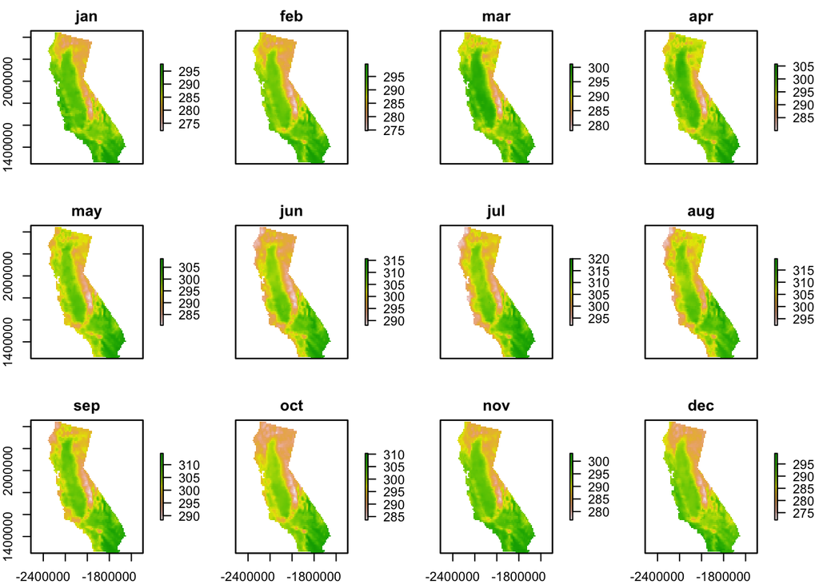

```r
# max temp
tmax_stack <- process_rasters(folder_path = "/tmax_2050")

# crop and mask to ca
tmax_stack_mask <- ca_crop_mask(tmax_stack, NAD83, california_project)

# convert to Kelvin
tmax_K <- tmax_stack_mask + 273.15

# plot
plot(tmax_K)
```

#### Average Minimum

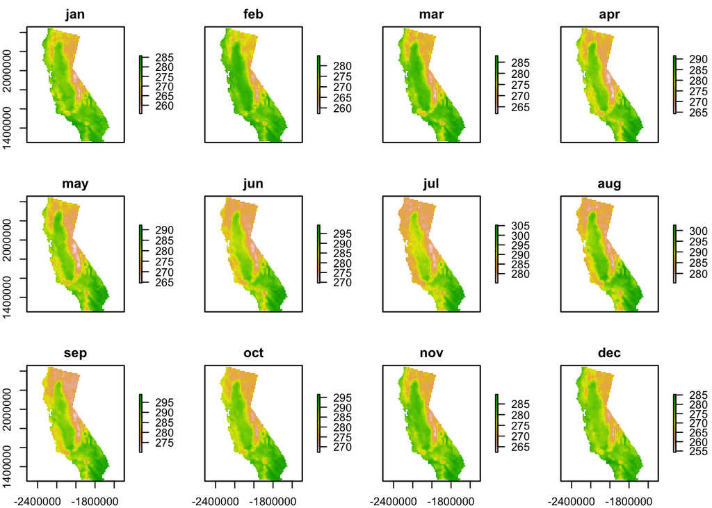

```r
# max temp
tmin_stack <- process_rasters(folder_path = "/tmin_2050")

# crop and mask to ca
tmin_stack_mask <- ca_crop_mask(tmin_stack, NAD83, california_project)

# convert to Kelvin
tmin_K <- tmin_stack_mask + 273.15

# plot
plot(tmin_K)
```

### Projected Energy Output Model

##### Parameters

**Gtotal**: Net solar irradiation (W/m^2)

**T**: average temperature (K)

**DTR**: daily temperature range - average temperature difference of the month

**Gday**: day-time insolation - Gtotal is total solar insolation (day + night) but we only need day time

**Tday_length**: daytime length of the location (hours)

**e_cell/e_ref**: efficiency of the photo voltaic (PV) panel

**T_ref**: room temperature is the reference temp (25 C)

**T_cell**: temperature of the solar panel

**B, g c1, c2, c2**: parameters

##### Equations

DTR = Tmax - Tmin

Gday = Gtotal * (24/Tday_length)

Tday = T + DIR/4

Tcell = c1 + c2(Tday) + c3(Gday)

eff = 1 - B(T_cell - T_ref) + g(log)(Gday)

Ppv = Gday(e_cell)

Energy output equation

```r
# function to calculate energy output for each month
energy_output = function(solar_raster, temp_raster, Tday_length){

  # calculate the average daily temperature range
  DTR = Tmax - Tmin

  # Calculate average daytime temperature
  Tday = T + DTR/4

  # calculate daytime solar radiation
  G_day = Gtotal*(24/Tday_length)

  # calculate temperature of PV cell
  Tcell = c1 + c2*Tday + c3*Gday

  # calculate efficiency of solar cells
  eff = 1 - B*(T_cell - T_ref) + g*log*Gday

  # calculate solar output
  solar_output = Gday*e_cell

  return(output)

}
```